This folder contains scripts used to calculate Gut Microbiome Health Index (GMHI) on the DMP data. GMHI was introduced in study by Gupta et al. (Nature Comm. 2020; https://www.nature.com/articles/s41467-020-18476-8 & https://github.com/jaeyunsung/GMHI_2020)

Briefly, the GMHI classifier is first applied on the discovery cohort to find the parameters which optimizes the balanced accuracy, i.e. the prevalence fold change (theta_f) and the prevalence difference (theta_d). Then the same classifier is run on the validation cohort, and from these results, the balanced accuracy corresponding to the optimized parameters (theta_f and theta_d found on the discovery cohort) is extracted.

**ANALYSIS 1:** Run the GMHI classifier to predict disease status (“healthy” vs “unhealthy”) based on our samples. We used a 90-10 training-testing split to generate a discovery (training data) and validation (testing data) cohort. * Testing step 1a: Calculate GMHI using the optimized parameters found in the training step for each stool metagenome in the validation cohort to investigate whether the distributions of GMHI differ between “healthy” and “unhealthy” disease status * Testing step 1b: Find the balance accuracy in the validation cohort that corresponds to the optimized *theta<sub>f</sub>* and *theta<sub>d</sub>* found in the training step

**NOTE:** This script implements GMHI calculation on *mock data* which does not have significant microbiome differences between healthy and unhealthy phenotypes and is intended for demonstration only. Real data can be obtained from EGA and Lifelines biobank (see DMP manuscript for details)

```r
library(tidyverse)
library(ggpubr)
alpha <- function(x){sum((log(x[x>0]))*(x[x>0]))*(-1)}

run_gmhi_classifier <- function(input_data, input_phenos) {

  input_phenos$MED.DISEASES.None.No.Diseases
  ip2 <- input_phenos[,c("MED.DISEASES.None.No.Diseases","sampleid")]

  data <- t(input_data) # taxa need to be on rows
  Healthy <- data[,colnames(data) %in% input_phenos[input_phenos$MED.DISEASES.None.No.Diseases %in% 1,]$sampleid]
  Nonhealthy <- data[,colnames(data) %in% input_phenos[input_phenos$MED.DISEASES.None.No.Diseases %in% 0,]$sampleid]

  n_samples_H <- ncol(Healthy)
  n_samples_NH <- ncol(Nonhealthy)
  n_samples_tot <- ncol(data)
  n_samples_H+n_samples_NH==n_samples_tot

  # PH: species prevalence among healthy
  # PNH: species prevalence among non-healthy
  PH <- apply(Healthy, 1, function(i) (sum(i > 0))*100/n_samples_H)
  PNH <- apply(Nonhealthy, 1, function(i) (sum(i > 0))*100/n_samples_NH)

  PH_diff <- (PH-PNH)
  PH_fold <- (PH/PNH)
  PNH_fold <- (PNH/PH)
  all_matrix <- data.frame(cbind(data,PH_diff,PH_fold,PNH_fold))

  # For the mock data, we had to adjust the values of theta_d and theta_f that we are testing
  theta_d <- c(-5,1,5) # difference
  theta_f <- seq(0, 4, by=0.1) # fold change

  # Gupta et al. (2020)
  # As it is common in microbiome data to have discrepancies between species’ relative abundances to span     several orders of magnitude, the geometric mean, rather than the arithmetic mean, is more appropriate to represent the mean relative abundance of MH species. More specifically, the Shannon’s diversity index, which is a weighted geometric mean (by definition) and commonly applied in ecological contexts, is used.

  alpha <- function(x){sum((log(x[x>0]))*(x[x>0]))*(-1)}

  report <- list()

  for(i in 1:length(theta_f)) {

    H_signature_sublist <- list()
    NH_signature_sublist <- list()
    report_sublist <- list()
    GMHI_list <- list()

    for(j in 1:length(theta_d)) {

      H_signature_sublist[[j]] <- data.frame(subset(as.matrix(all_matrix), all_matrix$PH_fold >= theta_f[i] & all_matrix$PH_diff >= theta_d[j]))
      NH_signature_sublist[[j]] <- data.frame(subset(as.matrix(all_matrix), all_matrix$PNH_fold >= theta_f[i] & all_matrix$PH_diff <= -theta_d[j]))

      H_shannon <- apply((H_signature_sublist[[j]][,-c(n_samples_tot:(n_samples_tot+3))]/100), 2, alpha)
      NH_shannon <- apply((NH_signature_sublist[[j]][,-c(n_samples_tot:(n_samples_tot+3))]/100), 2, alpha)

      H_sig_count <- apply(H_signature_sublist[[j]][,-c(n_samples_tot:(n_samples_tot+3))], 2, function(i) (sum(i > 0)))
      NH_sig_count <- apply(NH_signature_sublist[[j]][,-c(n_samples_tot:(n_samples_tot+3))], 2, function(i) (sum(i > 0)))

      constant <- data.frame(cbind(H_sig_count, NH_sig_count))

      HC1 <- constant[with(constant, order(-H_sig_count, NH_sig_count)), ]
      H_constant <- median(HC1$H_sig_count[1:floor(n_samples_H*0.01)])

      NHC1 <- constant[with(constant, order(H_sig_count, -NH_sig_count)), ]
      NH_constant <- median(NHC1$NH_sig_count[1:floor(n_samples_NH*0.01)])

      H_GMHI <- ((H_sig_count/H_constant)*H_shannon)
      NH_GMHI <- ((NH_sig_count/NH_constant)*NH_shannon)

      GMHI <- data.frame(log10((H_GMHI + 0.00001) / (NH_GMHI + 0.00001)))

      # Join our metadata
      GMHI <- GMHI %>%
        rownames_to_column("sampleid") %>%
        left_join(select(dat, sampleid, MED.DISEASES.None.No.Diseases), by="sampleid")

      Healthy_GMHI <- GMHI %>%
        filter(MED.DISEASES.None.No.Diseases==1) %>%
        column_to_rownames("sampleid") %>%
        rename(GMHI=1)

      Nonhealthy_GMHI <- GMHI %>%
        filter(MED.DISEASES.None.No.Diseases==0) %>%
        column_to_rownames("sampleid") %>%
        rename(GMHI=1)

      Healthy_accuracy <- sum(Healthy_GMHI$GMHI > 0) * 100 / n_samples_H
      Nonhealthy_accuracy <- sum(Nonhealthy_GMHI$GMHI < 0) * 100 / n_samples_NH

      total_accuracy <- (Healthy_accuracy + Nonhealthy_accuracy)
      total_average_accuracy <- (Healthy_accuracy + Nonhealthy_accuracy) / 2

      report_sublist[[j]] <- cbind(theta_f[i], theta_d[j],
                                   nrow(H_signature_sublist[[j]]), nrow(NH_signature_sublist[[j]]),
                                   H_constant, NH_constant,
                                   Healthy_accuracy, Nonhealthy_accuracy,
                                   total_accuracy, total_average_accuracy)
      report[[i]] <- report_sublist
    }
  }

  accuracy_table <- matrix(unlist(report), ncol=10, byrow=TRUE)
  colnames(accuracy_table) <- c("Fold change", "Difference",
                                "H_count","NH_count",
                                "H_constant", "NH_constant",
                                "Healthy accuracy", "Non-healthy accuracy",
                                "Total accuracy","Balanced accuracy")
  accuracy_table <- data.frame(accuracy_table) %>%
    arrange(desc(Balanced.accuracy))

  fold.change_optim <- accuracy_table[2,]$Fold.change
  difference_optim <- accuracy_table[2,]$Difference

  H_signature <- data.frame(subset(all_matrix, all_matrix$PH_fold >= fold.change_optim & all_matrix$PH_diff >= difference_optim))
  NH_signature <- data.frame(subset(all_matrix, all_matrix$PNH_fold >= fold.change_optim & all_matrix$PH_diff <= -difference_optim))

  return(list(accuracy_table,H_signature,NH_signature) )
}
```

```r
# define train/test splits based on mock data available in the GitHub repository

# load data
dat <- read.table("../Mock_data/diseases.txt") %>%
  rownames_to_column("sampleid")
taxa <- read.table("../Mock_data/taxa.txt")
# apply detection cut-off
taxa[taxa < 0.00001] <- 0
# drop non-informative taxa
taxa[,colSums(taxa) == 0] <- NULL

# Train split: 90% of the sample size
smp_size <- floor(0.9 * nrow(dat))

set.seed(123)
train_ind <- sample(seq_len(nrow(dat)), size = smp_size)

training_set <- taxa[train_ind,]
testing_set <- taxa[-train_ind,]
```

## ANALYSIS 1

```r
# Training step
discovery_ret <- run_gmhi_classifier(input_data = training_set, input_phenos=dat)
discovery <- discovery_ret[[1]]
#discovery <- discovery[!is.na(discovery),]

fold.change_optim <- discovery[2,]$Fold.change
difference_optim <- discovery[2,]$Difference

H_constant <- discovery[2,]$H_constant
NH_constant <- discovery[2,]$NH_constant

H_signature <- discovery_ret[[2]]
NH_signature <- discovery_ret[[3]]

H_species <- row.names(H_signature)
NH_species <- row.names(NH_signature)
```

```r
# Testing step 1a
# Calculate GMHI using the optimized parameters found in the training step for each stool metagenome in the validation cohort to investigate whether the distributions of GMHI differ between healthy" and "unhealthy" disease status.

# taxa has to be on rows
training <- t(training_set) # not used in this step
testing <- t(testing_set)

sp_H <- testing[row.names(testing) %in% H_species, ]
sp_NH <- testing[row.names(testing) %in% NH_species, ]

H_shannon <- apply((sp_H/100), 2, alpha)
NH_shannon <- apply((sp_NH/100), 2, alpha)

H_sig_count <- apply(sp_H, 2, function(i) (sum(i > 0)))
NH_sig_count <- apply(sp_NH, 2, function(i) (sum(i > 0)))

H_GMHI <- ((H_sig_count/H_constant)*H_shannon)
NH_GMHI <- ((NH_sig_count/NH_constant)*NH_shannon)

GMHI <- data.frame(GMHI=log10((H_GMHI + 0.00001) / (NH_GMHI + 0.00001)))

# GMHI classification
result <- data.frame(cbind(GMHI, H_sig_count, NH_sig_count, H_shannon, NH_shannon, H_GMHI, NH_GMHI))

result <- result %>%
  rownames_to_column("sampleid") %>%
  left_join(select(dat, sampleid, MED.DISEASES.None.No.Diseases), by="sampleid")

# output result
discovery[2,]
```

```
##   Fold.change Difference H_count NH_count H_constant NH_constant
## 2         0.1          1      32       28         23          15
##   Healthy.accuracy Non.healthy.accuracy Total.accuracy Balanced.accuracy
## 2         65.48387             52.54237       118.0262          59.01312
```

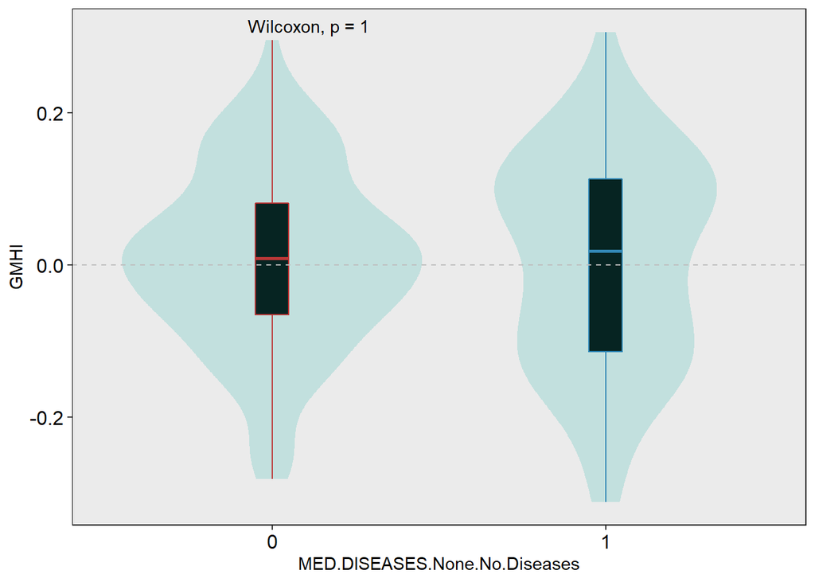

```r
# Plot the prediction
result %>%
  mutate(MED.DISEASES.None.No.Diseases=factor(MED.DISEASES.None.No.Diseases)) %>%
  ggplot(aes(x = MED.DISEASES.None.No.Diseases, y = GMHI, fill = MED.DISEASES.None.No.Diseases, color = MED.DISEASES.None.No.Diseases)) +
  geom_boxplot(outlier.size = 2,
               fill = "black",
               na.rm = TRUE,
               width = .1,
               notch = F) +
  geom_violin(alpha = .2,
              fill = "lightseagreen",
              colour = NA,
              na.rm = TRUE) +
  scale_color_brewer(palette = "Set1") +
  theme(legend.position = "none",
        panel.grid.major = element_blank(),
        panel.grid.minor = element_blank(),
        panel.border = element_rect(colour="black", fill = NA, size = 0.5),
        axis.text = element_text(size=12, color = "black")) +
  geom_hline(yintercept = 0, linetype = "dashed", color = "gray") +
  stat_compare_means()
```

```r
write.csv(result, paste0("GMHI_result_", "train_", deparse(substitute(training_set)), "_test_",    deparse(substitute(testing_set)),".csv"), row.names=F)
```

```r
# Testing step 1b
# Find the balance accuracy in the validation cohort that corresponds to optimized theta_f and theta_d found in the training step
validation <- run_gmhi_classifier(input_data = testing_set,input_phenos = dat)[[1]]

validation %>% filter(Fold.change==fold.change_optim & Difference==difference_optim)
```

```
##   Fold.change Difference H_count NH_count H_constant NH_constant
## 1         0.1          1      43       41         27          20
##   Healthy.accuracy Non.healthy.accuracy Total.accuracy Balanced.accuracy
## 1         40.78947             88.70968       129.4992          64.74958
```